# Constrained Pair Matching

Detailled Script.

Tarik Benmarhnia https://profiles.ucsd.edu/tarik.benmarhnia (UCSD & Scripps Institute)https://benmarhniaresearch.ucsd.edu/ , Marie-Abèle Bind https://scholar.harvard.edu/marie-abele (Biostatistics Center, Massachusetts General Hospital)https://biostatistics.massgeneral.org/faculty/marie-abele-bind-phd/ , Léo Zabrocki https://lzabrocki.github.io/ (Paris School of Economics)https://www.parisschoolofeconomics.eu/fr/zabrocki-leo/  
2022-01-20

In this document, we provide all steps and R codes required to estimate the effect of heat waves of the number of years of life lost (YoLL) using a recently developed constrained pair matching algorithm. Compared to propensity score matching, we can choose the maximum distance allowed between treated and control units for each covariate. The coding procedure is a bit more involved as it has not been formatted in an R package yet. **Should you have any questions, need help to reproduce the analysis or find coding errors, please do not hesitate to contact us at leo.zabrocki@psemail.eu**

# Required Packages and Data Loading

To reproduce exactly the `6_constrained_pair_matching.html` document, we first need to have installed:

- the [R](https://www.r-project.org/) programming language
- [RStudio](https://rstudio.com/), an integrated development environment for R, which will allow you to knit the `6_constrained_pair_matching.Rmd` file and interact with the R code chunks
- the [R Markdown](https://rmarkdown.rstudio.com/) package
- and the [Distill](https://rstudio.github.io/distill/) package which provides the template for this document.

Once everything is set up, we load the following packages:

```r
# load required packages
library(knitr) # for creating the R Markdown document
library(here) # for files paths organization
library(tidyverse) # for data manipulation and visualization
library(broom) # for cleaning regression outputs
library(Rcpp) # for running the matching algorithm
library(optmatch) # for matching pairs
library(igraph) # for maximum bipartite matching
library(lmtest) # for modifying regression standard errors
library(sandwich) # for robust and cluster robust standard errors
library(Cairo) # for printing custom police of graphs
library(DT) # for displaying the data as tables
```

We also have to load the `script_time_series_matching_function.R` located in the **functions** folder and which provides the functions used for matching time series:

```r
# load matching functions
source(here::here(
  "2.scripts",
  "functions",
  "script_time_series_matching_function.R"
))
```

We load our custom `ggplot2` theme for graphs:

```r
# load ggplot custom theme
source(here::here("2.scripts",
                  "functions",
                  "script_theme_tufte.R"))
# define nice colors
my_blue <- "#0081a7"
my_orange <- "#fb8500"
```

We finally load the data:

```r
# load the data
matching_data <-
  readRDS(here::here("1.data", "simulated_environmental_data.rds")) %>%
  mutate_at(vars(weekday, month), ~ as.factor(.) %>% as.numeric(.)) %>%
  mutate(d_year = lubridate::yday(date))
```

# Matching Procedure

### Defining the Treatment of Interest

We defined our experiment such that:

- treated units are days where an heat wave occurred in *t*.
- control units are day no heat wave occurred in *t*.

Below are the required steps to define treatment variable (`is_treated`) and select the corresponding treated and control units:

```r
# define treatment variable
matching_data <- matching_data %>%
  mutate(is_treated = ifelse(heat_wave == 1, TRUE, FALSE))

# subset treated and control units
treated_units = subset(matching_data, is_treated)
control_units = subset(matching_data,!is_treated)
N_treated = nrow(treated_units)
N_control = nrow(control_units)
```

There are 122 treated units and 1254 control units. We display the distribution of of treated and control units through time:

**Please show me the code!**

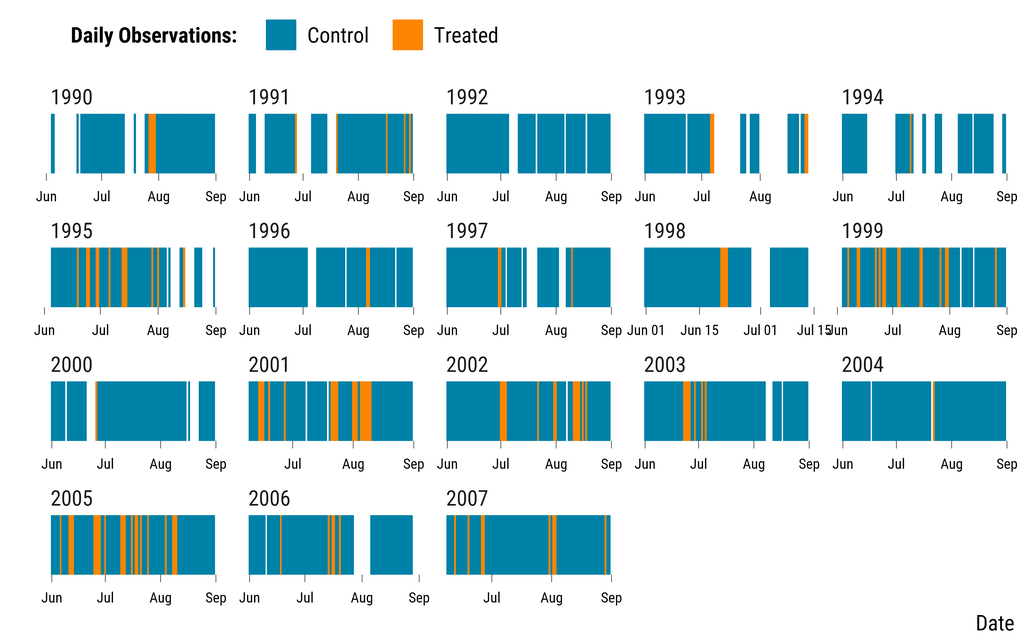

```r
# make stripes graph
matching_data %>%
  mutate(is_treated = ifelse(is_treated == "TRUE", "Treated", "Control")) %>%
  ggplot(., aes(x = date, y = 1, fill = is_treated)) +
  geom_tile() +
  scale_y_continuous(expand = c(0, 0)) +
  facet_wrap(~ year, scales = "free") +
  scale_fill_manual(name = "Daily Observations:", values = c(my_blue, my_orange)) +
  xlab("Date") + ylab("") +
  theme_tufte() +
  theme(axis.ticks.y = element_blank(),
        axis.text.y = element_blank())
```

We save the `matching_data`:

```r
saveRDS(
  matching_data,
  here::here(
    "3.outputs",
    "1.data",
    "constrained_pair_matching",
    "matching_data.rds"
  )
)
```

### Defining Thresholds for Matching Covariates

For each relevant covariate, we must define a maximum distance for which a treated unit can be matched to a control unit. We chose the distance to maximize covariates balance but also reach a number of matched treated units large enough to draw our inference upon:

Below is the code to define the relevant thresholds:

```r
# we create the scaling list as it is needed for running the algorithm
# but we do not use it

scaling =  rep(list(1),ncol(matching_data))
names(scaling) = colnames(matching_data)

# instead, we manually defined the threshold for each covariate
thresholds = rep(list(Inf),ncol(matching_data))
names(thresholds) = colnames(matching_data)

# threshold for year
thresholds$year = 4

# threshold for weekday
thresholds$weekday = 0

# thresholds for season
thresholds$d_year = 30

# threshold for heat_wave lags
thresholds$heat_wave_lag_1 = 0
thresholds$heat_wave_lag_2 = 0
thresholds$heat_wave_lag_3 = 0

# threshold for humidity_relative
thresholds$humidity_relative = 10

# threshold for o3
thresholds$o3_lag_1 = 12
thresholds$o3_lag_2 = 12
thresholds$o3_lag_3 = 12

# thresholds for no2
thresholds$no2 = 9
thresholds$no2_lag_1 = 9
thresholds$no2_lag_2 = 9
thresholds$no2_lag_3 = 9
```

### Running the Matching Procedure

We compute discrepancy matrix and run the matching algorithm:

```r
# first we compute the discrepancy matrix
discrepancies = discrepancyMatrix(treated_units, control_units, thresholds, scaling)

# convert matching data to data.frame
matching_data <- as.data.frame(matching_data)

rownames(discrepancies) = format(matching_data$date[which(matching_data$is_treated)],"%Y-%m-%d")
colnames(discrepancies) = format(matching_data$date[which(!matching_data$is_treated)],"%Y-%m-%d")
rownames(matching_data) = matching_data$date

# run the fullmatch algorithm
matched_groups = fullmatch(discrepancies, data = matching_data, remove.unmatchables = TRUE, max.controls = 1)

# get list of matched  treated-control groups
groups_labels = unique(matched_groups[!is.na(matched_groups)])
groups_list = list()
for (i in 1:length(groups_labels)){
  IDs = names(matched_groups)[(matched_groups==groups_labels[i])]
  groups_list[[i]] = as.Date(IDs[!is.na(IDs)])
}
```

For some cases, several controls units were matched to a treatment unit. We use the `igraph` package to force pair matching via bipartite maximal weighted matching. Below is the required code:

```r
# we build a bipartite graph with one layer of treated nodes, and another layer of control nodes.
# the nodes are labeled by integers from 1 to (N_treated + N_control)
# by convention, the first N_treated nodes correspond to the treated units, and the remaining N_control
# nodes correspond to the control units.

# build pseudo-adjacency matrix: edge if and only if match is admissible
# NB: this matrix is rectangular so it is not per say the adjacendy matrix of the graph
# (for this bipartite graph, the adjacency matrix had four blocks: the upper-left block of size
# N_treated by N_treated filled with 0's, bottom-right block of size N_control by N_control filled with 0's,
# top-right block of size N_treated by N_control corresponding to adj defined below, and bottom-left block
# of size N_control by N_treated corresponding to the transpose of adj)
adj = (discrepancies<Inf)

# extract endpoints of edges
edges_mat = which(adj,arr.ind = TRUE)

# build weights, listed in the same order as the edges (we use a decreasing function x --> 1/(1+x) to
# have weights inversely proportional to the discrepancies, since maximum.bipartite.matching
# maximizes the total weight and we want to minimize the discrepancy)
weights = 1/(1+sapply(1:nrow(edges_mat),function(i)discrepancies[edges_mat[i,1],edges_mat[i,2]]))

# format list of edges (encoded as a vector resulting from concatenating the end points of each edge)
# i.e c(edge1_endpoint1, edge1_endpoint2, edge2_endpoint1, edge2_endpoint1, edge3_endpoint1, etc...)
edges_mat[,"col"] = edges_mat[,"col"] + N_treated
edges_vector = c(t(edges_mat))

# NB: by convention, the first N_treated nodes correspond to the treated units, and the remaining N_control
# nodes correspond to the control units (hence the "+ N_treated" to shift the labels of the control nodes)

# build the graph from the list of edges
BG = make_bipartite_graph(c(rep(TRUE,N_treated),rep(FALSE,N_control)), edges = edges_vector)

# find the maximal weighted matching
MBM = maximum.bipartite.matching(BG, weights = weights)

# list the dates of the matched pairs
pairs_list = list()
N_matched = 0
for (i in 1:N_treated){
  if (!is.na(MBM$matching[i])){
    N_matched = N_matched + 1
    pairs_list[[N_matched]] = c(treated_units$date[i],control_units$date[MBM$matching[i]-N_treated])
  }
}

# transform the list of matched pairs to a dataframe
matched_pairs <- enframe(pairs_list) %>%
  unnest(cols = "value") %>%
  rename(pair_number = name,
         date = value)
```

The hypothetical experiment we set up had 122 treated units and 1254 control units. The matching procedure results in 36 matched treated units.

We finally merge the `matched_pairs` with the `matching_matching_data` to retrieve covariates values for the matched pairs and save the data:

```r
# select the matched data for the analysis
final_data <-
  left_join(matched_pairs, matching_data, by = "date") %>%
  mutate(pair_number = as.factor(pair_number))

# save the matched data
saveRDS(
  final_data,
  here::here(
    "3.outputs",
    "1.data",
    "constrained_pair_matching",
    "matched_data.Rds"
  )
)
```

# Checking Covariates Balance Improvement

We first bind the matching and matched data together:

```r
# bind the two datasets
matching_data <- matching_data %>%
  mutate(dataset = "Initial Data")

final_data <- final_data %>%
    mutate(dataset = "Matched Data")

data <- bind_rows(matching_data, final_data)
```

We change labels of the `is_treated` variable :

```r
data <- data %>%
  mutate(is_treated = ifelse(is_treated == "TRUE", "True", "False"))
```

We then assess covariates balance using love plots:

### Continuous Covariates

For continuous covariates, we compute and plot the standardized mean differences:

**Please show me the code!**

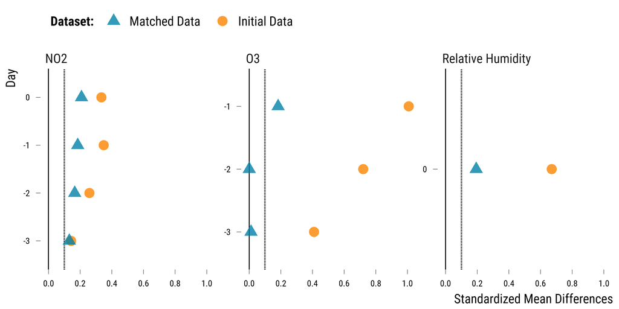

```r
# compute figures for the love plot
data_cov_continuous <- data %>%
  select(dataset, is_treated, contains("humidity_relative"), o3_lag_1:o3_lag_3, no2:no2_lag_3) %>%
  pivot_longer(cols = -c(is_treated, dataset), names_to = "variable", values_to = "values") %>%
  mutate(continuous_variable = NA %>%
           ifelse(str_detect(variable, "o3"), "O3",.) %>%
           ifelse(str_detect(variable, "humidity_relative"), "Relative Humidity",.) %>%
           ifelse(str_detect(variable, "no2"), "NO2",.)) %>%
    mutate(time = "0" %>%
           ifelse(str_detect(variable, "lag_1"), "-1", .) %>%
           ifelse(str_detect(variable, "lag_2"), "-2", .) %>%
           ifelse(str_detect(variable, "lag_3"), "-3", .)) %>%
  mutate(time = fct_relevel(time, "-3", "-2", "-1", "0")) %>%
  select(dataset, is_treated, continuous_variable, time, values)

data_abs_difference_continuous <- data_cov_continuous %>%
  group_by(dataset, continuous_variable, time, is_treated) %>%
  summarise(mean_values = mean(values, na.rm = TRUE)) %>%
  summarise(abs_difference = abs(mean_values[2]-mean_values[1]))

data_sd_continuous <-  data_cov_continuous %>%
  filter(is_treated == "True") %>%
  group_by(dataset, continuous_variable, time, is_treated) %>%
  summarise(sd_treatment = sd(values, na.rm = TRUE)) %>%
  ungroup() %>%
  select(dataset, continuous_variable, time, sd_treatment)

data_love_continuous <- left_join(data_abs_difference_continuous, data_sd_continuous, by = c("dataset", "continuous_variable", "time")) %>%
  mutate(standardized_difference = abs_difference/sd_treatment) %>%
  select(-c(abs_difference,sd_treatment))

# make the graph
graph_cpm_love_plot_1 <- ggplot(data_love_continuous, aes(y = time, x = standardized_difference, colour = fct_rev(dataset), shape = fct_rev(dataset))) +
  geom_vline(xintercept = 0, size = 0.3) +
  geom_vline(xintercept = 0.1, color = "black", linetype = "dashed") +
  geom_point(size = 4, alpha = 0.8) +
  scale_x_continuous(breaks = scales::pretty_breaks(n = 5)) +
  scale_colour_manual(name = "Dataset:", values = c(my_blue, my_orange)) +
  scale_shape_manual(name = "Dataset:", values = c(17, 16)) +
  facet_wrap(~ continuous_variable, scales = "free_y") +
  xlab("Standardized Mean Differences") +
  ylab("Day") +
  theme_tufte()

# display the graph
graph_cpm_love_plot_1
```

**Please show me the code!**

```r
# save the graph
ggsave(
  graph_cpm_love_plot_1,
  filename = here::here(
    "3.outputs",
    "2.graphs",
    "graph_cpm_love_plot_1.pdf"
  ),
  width = 20,
  height = 15,
  units = "cm",
  device = cairo_pdf
)
```

### Calendar Indicators

For calendar indicators, we compute and plot the absolute differences in proportions:

```r
# compute figures for the love plot
data_calendar <- data %>%
  mutate(weekday = lubridate::wday(date, abbr = FALSE, label = TRUE)) %>%
  select(dataset, is_treated, weekday, month, year) %>%
  mutate_all(~ as.character(.)) %>%
  pivot_longer(cols = -c(dataset, is_treated), names_to = "variable", values_to = "values") %>%
  # group by is_treated, variable and values
  group_by(dataset, is_treated, variable, values) %>%
  # compute the number of observations
  summarise(n = n()) %>%
  # compute the proportion
  mutate(freq = round(n / sum(n)*100, 0)) %>%
  ungroup() %>%
  mutate(calendar_variable = NA %>%
           ifelse(str_detect(variable, "weekday"), "Day of the Week",.) %>%
           ifelse(str_detect(variable, "month"), "Month",.) %>%
           ifelse(str_detect(variable, "year"), "Year",.)) %>%
  select(dataset, is_treated, calendar_variable, values, freq) %>%
  pivot_wider(names_from = is_treated, values_from = freq) %>%
  mutate(abs_difference = abs(`True` - `False`)) %>%
  filter(values != "False")
```

Plot for days of the week:

**Please show me the code!**

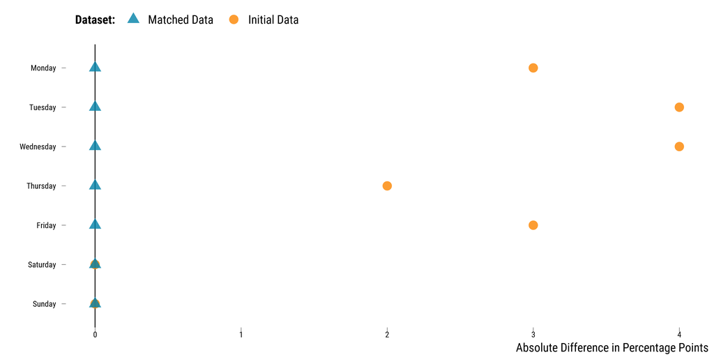

```r
# graph for weekdays
graph_cpm_love_plot_2 <- data_calendar %>%
  filter(calendar_variable == "Day of the Week") %>%
  mutate(
    values = fct_relevel(
      values,
      "Monday",
      "Tuesday",
      "Wednesday",
      "Thursday",
      "Friday",
      "Saturday",
      "Sunday"
    )
  ) %>%
  ggplot(., aes(
    y = fct_rev(values),
    x = abs_difference,
    colour = fct_rev(dataset),
    shape = fct_rev(dataset)
  )) +
  geom_vline(xintercept = 0, size = 0.3) +
  geom_point(size = 4, alpha = 0.8) +
  scale_colour_manual(name = "Dataset:", values = c(my_blue, my_orange)) +
  scale_shape_manual(name = "Dataset:", values = c(17, 16)) +
  xlab("Absolute Difference in Percentage Points") +
  ylab("") +
  theme_tufte() +
  theme(axis.text.x = element_text(margin = ggplot2::margin(t = 0, unit = "cm")))

# display the graph
graph_cpm_love_plot_2
```

**Please show me the code!**

```r
# save the graph
ggsave(
  graph_cpm_love_plot_2,
  filename = here::here(
    "3.outputs",
    "2.graphs",
    "graph_cpm_love_plot_2.pdf"
  ),
  width = 20,
  height = 15,
  units = "cm",
  device = cairo_pdf
)
```

Plot for months:

**Please show me the code!**

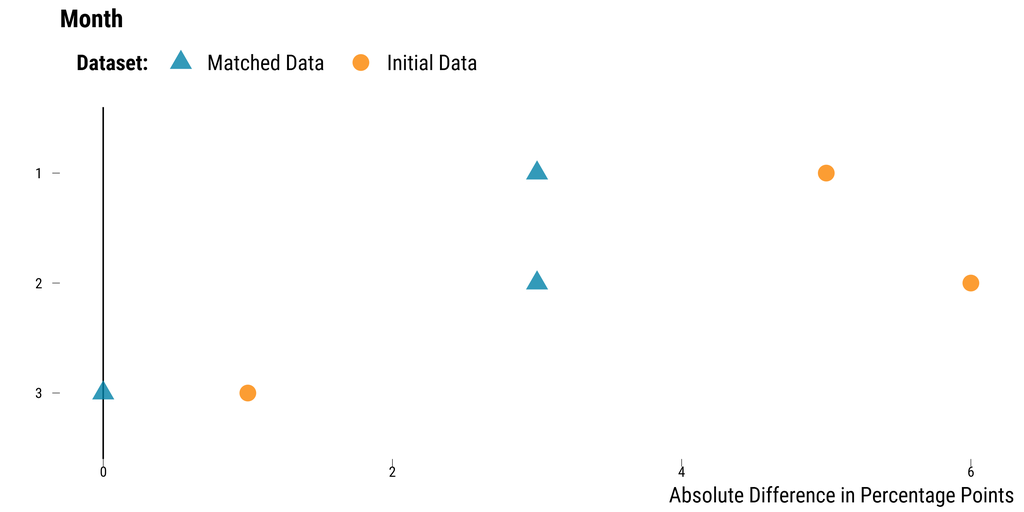

```r
# graph for month
graph_cpm_love_plot_3 <- data_calendar %>%
  filter(calendar_variable == "Month") %>%
  mutate(
    values = fct_relevel(
      values,
      "January",
      "February",
      "March",
      "April",
      "May",
      "June",
      "July",
      "August",
      "September",
      "October",
      "November",
      "December"
    )
  ) %>%
  ggplot(., aes(
    y = fct_rev(values),
    x = abs_difference,
    colour = fct_rev(dataset),
    shape = fct_rev(dataset)
  )) +
  geom_vline(xintercept = 0, size = 0.3) +
  geom_point(size = 4, alpha = 0.8) +
  scale_colour_manual(name = "Dataset:", values = c(my_blue, my_orange)) +
  scale_shape_manual(name = "Dataset:", values = c(17, 16)) +
  ggtitle("Month") +
  xlab("Absolute Difference in Percentage Points") +
  ylab("") +
  theme_tufte() +
  theme(axis.text.x = element_text(margin = ggplot2::margin(t = 0, unit = "cm")))

# display the graph
graph_cpm_love_plot_3
```

**Please show me the code!**

```r
# save the graph
ggsave(
  graph_cpm_love_plot_3,
  filename = here::here(
    "3.outputs",
    "2.graphs",
    "graph_cpm_love_plot_3.pdf"
  ),
  width = 20,
  height = 15,
  units = "cm",
  device = cairo_pdf
)
```

Plot for years:

**Please show me the code!**

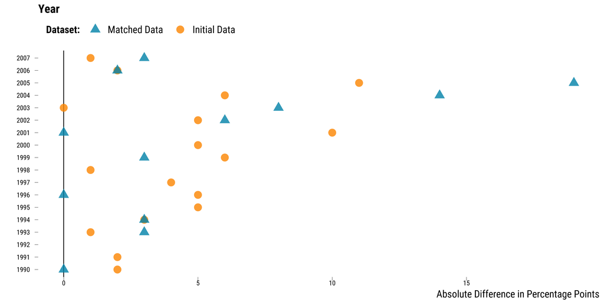

```r
# graph for year
graph_cpm_love_plot_4 <- data_calendar %>%
  filter(calendar_variable == "Year") %>%
  ggplot(., aes(
    y = as.factor(as.numeric(values)),
    x = abs_difference,
    colour = fct_rev(dataset),
    shape = fct_rev(dataset)
  )) +
  geom_vline(xintercept = 0, size = 0.3) +
  geom_point(size = 4, alpha = 0.8) +
  scale_colour_manual(name = "Dataset:", values = c(my_blue, my_orange)) +
  scale_shape_manual(name = "Dataset:", values = c(17, 16)) +
  ggtitle("Year") +
  xlab("Absolute Difference in Percentage Points") +
  ylab("") +
  theme_tufte() +
  theme(axis.text.x = element_text(margin = ggplot2::margin(t = 0, unit = "cm")))

# display the graph
graph_cpm_love_plot_4
```

**Please show me the code!**

```r
# save the graph
ggsave(
  graph_cpm_love_plot_4,
  filename = here::here(
    "3.outputs",
    "2.graphs",
    "graph_cpm_love_plot_4.pdf"
  ),
  width = 20,
  height = 15,
  units = "cm",
  device = cairo_pdf
)
```

### Love Plot Similar to `Cobalt`

We plot below the love plot for all variables used in the propensity score matching procedure to compare the balance with the constrained pair matching procedure:

**Please show me the code!**

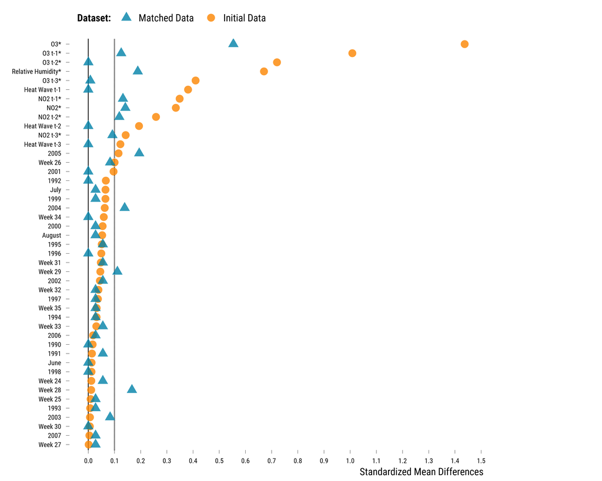

```r
# compute absolute standardized mean differences for continuous covariates
data_cov_continuous <- data %>%
  select(dataset, is_treated, humidity_relative, o3:no2_lag_3) %>%
  pivot_longer(
    cols = -c(is_treated, dataset),
    names_to = "variable",
    values_to = "values"
  ) %>%
  select(dataset, is_treated, variable, values)

data_abs_difference_continuous <- data_cov_continuous %>%
  group_by(dataset, variable, is_treated) %>%
  summarise(mean_values = mean(values, na.rm = TRUE)) %>%
  summarise(abs_difference = abs(mean_values[2] - mean_values[1]))

data_sd_continuous <- data_cov_continuous %>%
  filter(dataset == "Initial Data" & is_treated == "True") %>%
  group_by(variable) %>%
  summarise(sd_treatment = sd(values, na.rm = TRUE)) %>%
  ungroup() %>%
  select(variable, sd_treatment)

data_love_continuous <-
  left_join(data_abs_difference_continuous, data_sd_continuous, by = c("variable")) %>%
  mutate(standardized_difference = abs_difference / sd_treatment) %>%
  select(-c(abs_difference, sd_treatment)) %>%
  mutate(type = "continuous")


# compute absolute raw mean differences for binary covariates
data_cov_binary <- data %>%
  select(dataset, is_treated, heat_wave_lag_1:heat_wave_lag_3, week_24:year_2007) %>%
  pivot_longer(
    cols = -c(is_treated, dataset),
    names_to = "variable",
    values_to = "values"
  ) %>%
  select(dataset, is_treated, variable, values)

data_love_binary <- data_cov_binary %>%
  group_by(dataset, variable, is_treated) %>%
  summarise(mean_values = mean(values, na.rm = TRUE)) %>%
  summarise(standardized_difference = abs(mean_values[2] - mean_values[1])) %>%
  mutate(type = "binary")


# combine the two datasets
data_love <- bind_rows(data_love_continuous, data_love_binary)

# add variable labels
data_love <- data_love %>%
  mutate(
    variable = case_when(
      variable == "heat_wave_lag_1" ~ "Heat Wave t-1",
      variable == "heat_wave_lag_2" ~ "Heat Wave t-2",
      variable == "heat_wave_lag_3" ~ "Heat Wave t-3",
      variable == "humidity_relative" ~ "Relative Humidity*",
      variable == "month_august" ~ "August",
      variable == "month_july" ~ "July",
      variable == "month_june" ~ "June",
      variable == "no2" ~ "NO2*",
      variable == "no2_lag_1" ~ "NO2 t-1*",
      variable == "no2_lag_2" ~ "NO2 t-2*",
      variable == "no2_lag_3" ~ "NO2 t-3*",
      variable == "o3" ~ "O3*",
      variable == "o3_lag_1" ~ "O3 t-1*",
      variable == "o3_lag_2" ~ "O3 t-2*",
      variable == "o3_lag_3" ~ "O3 t-3*",
      variable == "week_22" ~ "Week 22",
      variable == "week_23" ~ "Week 23",
      variable == "week_24" ~ "Week 24",
      variable == "week_25" ~ "Week 25",
      variable == "week_26" ~ "Week 26",
      variable == "week_27" ~ "Week 27",
      variable == "week_28" ~ "Week 28",
      variable == "week_29" ~ "Week 29",
      variable == "week_30" ~ "Week 30",
      variable == "week_31" ~ "Week 31",
      variable == "week_32" ~ "Week 32",
      variable == "week_33" ~ "Week 33",
      variable == "week_34" ~ "Week 34",
      variable == "week_35" ~ "Week 35",
      variable == "year_1990" ~ "1990",
      variable == "year_1991" ~ "1991",
      variable == "year_1992" ~ "1992",
      variable == "year_1993" ~ "1993",
      variable == "year_1994" ~ "1994",
      variable == "year_1995" ~ "1995",
      variable == "year_1996" ~ "1996",
      variable == "year_1997" ~ "1997",
      variable == "year_1998" ~ "1998",
      variable == "year_1999" ~ "1999",
      variable == "year_2000" ~ "2000",
      variable == "year_2001" ~ "2001",
      variable == "year_2002" ~ "2002",
      variable == "year_2003" ~ "2003",
      variable == "year_2004" ~ "2004",
      variable == "year_2005" ~ "2005",
      variable == "year_2006" ~ "2006",
      variable == "year_2007" ~ "2007"
    )
  )

# arrange the dataset
data_love <- data_love %>%
  arrange(dataset, standardized_difference) %>%
  mutate(variable=factor(variable, levels=variable))

# make the graph
graph_cpm_love_plot_cobalt <- ggplot(data_love, aes(y = variable, x = standardized_difference, colour = fct_rev(dataset), shape = fct_rev(dataset))) +
  geom_vline(xintercept = 0, size = 0.3) +
  geom_vline(xintercept = 0.1, color = "black", linetype = "dashed") +
  geom_point(size = 4, alpha = 0.8) +
  scale_x_continuous(breaks = scales::pretty_breaks(n = 12)) +
  scale_colour_manual(name = "Dataset:", values = c(my_blue, my_orange)) +
  scale_shape_manual(name = "Dataset:", values = c(17, 16)) +
  xlab("Standardized Mean Differences") +
  ylab("") +
  theme_tufte() +
  theme(plot.margin = margin(t = 0.25, r = 5, b = 0.25, l = 0, unit = "cm"))

# display the graph
graph_cpm_love_plot_cobalt
```

**Please show me the code!**

```r
# save the graph
ggsave(
  graph_cpm_love_plot_cobalt,
  filename = here::here(
    "3.outputs",
    "2.graphs",
    "graph_cpm_love_plot_cobalt.pdf"
  ),
  width = 30,
  height = 18,
  units = "cm",
  device = cairo_pdf
)
```

We display below the evolution of the average of standardized mean differences for continuous covariates:

**Please show me the code!**

```r
data_love %>%
  filter(type == "continuous") %>%
  group_by(dataset) %>%
  summarise("Average of Mean Differences" = round(mean(standardized_difference), 2),
            "Std. Deviation of Mean Differences" = round(sd(standardized_difference), 2)) %>%
  kable(align = c("l", "c"))
```

| dataset | Average of Mean Differences | Std. Deviation of Mean Differences |
| --- | --- | --- |
| Initial Data | 0.59 | 0.42 |
| Matched Data | 0.15 | 0.16 |

We also display below the evolution of the difference in proportions for binary covariates:

**Please show me the code!**

```r
data_love %>%
  filter(type == "binary") %>%
  group_by(dataset) %>%
  summarise("Average of Mean Differences" = round(mean(standardized_difference), 2),
            "Std. Deviation of Mean Differences" = round(sd(standardized_difference), 2)) %>%
  kable(align = c("l", "c"))
```

| dataset | Average of Mean Differences | Std. Deviation of Mean Differences |
| --- | --- | --- |
| Initial Data | 0.05 | 0.07 |
| Matched Data | 0.04 | 0.05 |

Overall, the balance has improved for continuous covariates after matching. It is not really the case for binary variables.

# Analysing Results

We must be careful when we analyze the results as only 36 treated units were matched: the estimand is no longer the ATT. To know the true causal effect, we must compute the average difference in potential outcomes:

```r
# compute the true effect for the data
true_att <-
  round(mean(final_data$y_1[final_data$is_treated == TRUE] - final_data$y_0[final_data$is_treated == FALSE]), 0)
```

The true causal effect is equal to + 234. We then compute the estimate using a simple linear regression model:

```r
# we fit the regression model
model <-
  lm(
    y_obs ~ is_treated,
    data = final_data
  )

# retrieve the estimate and 95% ci
results <- tidy(coeftest(
  model,
  vcov. = vcovCL,
  cluster = ~ pair_number
),
conf.int = TRUE) %>%
  filter(term == "is_treatedTRUE") %>%
  select(term, estimate, conf.low, conf.high) %>%
  mutate_at(vars(estimate:conf.high), ~ round(., 0))

# display results
results %>%
  rename(
    "Term" = term,
    "Estimate" = estimate,
    "95% CI Lower Bound" = conf.low,
    "95% CI Upper Bound" = conf.high
  ) %>%
  kable(., align = c("l", "c", "c", "c"))
```

| Term | Estimate | 95% CI Lower Bound | 95% CI Upper Bound |
| --- | --- | --- | --- |
| is_treatedTRUE | 234 | 167 | 300 |

We find that the average effect on the treated is equal to +234 years of life lost: the estimate is equal to the true true effect. The 95% confidence interval is however wide and is consistent with effects ranging from +167 up to +300.

We finally save the data on constrained pair matching results in the `3.outputs/1.data/analysis_results` folder.

**Please show me the code!**

```r
results %>%
  mutate(
    procedure = "Constrained Pair Matching",
    true_effect = true_att,
    sample_size = N_matched*2
  ) %>%
  saveRDS(
    .,
    here::here(
      "3.outputs",
      "1.data",
      "analysis_results",
      "data_analysis_cpm.RDS"
    )
  )
```